# Human Activity Recognition

Mickey Kislev

7 7 2021

### Loading the data

The data was saved locally and uploaded by its csv file.

```r
# Load packages
requiredPackages <- c('tidyverse', 'R.utils', 'caret', 'rattle', 'rmarkdown');
for(p in requiredPackages){
  if(!require(p,character.only = TRUE)) install.packages(p)
  library(p,character.only = TRUE)
}
rm(p, requiredPackages)


# Save a copy locally
if (!file.exists("pml-training.csv")) {
  download.file("https://d396qusza40orc.cloudfront.net/predmachlearn/pml-training.csv","pml-training.csv")
}

if (!file.exists("pml-testing.csv")) {
  download.file("https://d396qusza40orc.cloudfront.net/predmachlearn/pml-testing.csv","pml-testing.csv")
}

Source_training <- read.csv("pml-training.csv",
                      stringsAsFactors = FALSE,
                      na.strings = "#DIV/0!",
                      skipNul = TRUE);

Source_prediction <- read.csv("pml-testing.csv",
                     stringsAsFactors = FALSE,
                     na.strings = "#DIV/0!",
                     skipNul = TRUE);
```

An empty field was defined as “#DIV/0!” in the original file, so I used the “na.strings” definition to convert them to NA fields. I also difine a skiping of empty colomns by using the “skipNul” definition.

### The preparation of the data

Then I run several commands for cleaning of close to 0 variable, which are not indicative, using the following script:

```r
# remove variables with Nearly Zero Variance
near_zero <- nearZeroVar(Source_training)
Source_training <- Source_training[, -near_zero]
Source_prediction  <- Source_prediction[, -near_zero]
dim(Source_training)
```

```
## [1] 19622    83
```

I Added to that a cleaning of the data from unfilled columns

```r
# Clean NA's fields
NA_clean <- apply(Source_training,2,function(x) {sum(is.na(x))})
Source_training <- Source_training[,which(NA_clean == 0)]
NA_clean <- apply(Source_prediction,2,function(x) {sum(is.na(x))})
Source_prediction <- Source_prediction[,which(NA_clean == 0)]
dim(Source_training)
```

```
## [1] 19622    59
```

Finally, Ideleted the first 7 columns which contain technical information of date and user name.

```r
# Delete the first 7 veriables which are not relevent
Source_training <- Source_training[,-c(1:7)]
Source_prediction <- Source_prediction[,-c(1:7)]
dim(Source_training)
```

```
## [1] 19622    52
```

### Creating a model

Since the data contain such a large number of observation, It was possible to split the data into three subsets of: train (60%), test (20%) and validation (20%) sets:

```r
set.seed(685)
inTrain <- createDataPartition(y=Source_training$classe,
                               p=0.6, list=FALSE)
training <- Source_training[inTrain,]
testing <- Source_training[-inTrain,]

# create the test and the validation sets
inTest <- createDataPartition(y=testing$classe, p=0.5, list=FALSE)
validation <- testing[inTest,]
testing <- testing[-inTest,]
```

I, than, commanded the R consule to calculate for me the best variables and the conditions, which anentually will become the model, for predicting the participent to lift dumbbell performance (var. “Classe”)

```r
# Choosing the veriables
modFit <- train(classe ~ .,
                method="rpart",
                trControl = trainControl(method = "repeatedcv", number = 5, repeats = 5),
                data=training,
                tuneLength = 52)
print(modFit$finalModel)
```

[output not shown]

I used the CART model using the method “rpart”, using a cross-validation several time using the “repeatedcv” method. the reasults graphically looks as presented in fig. 1:

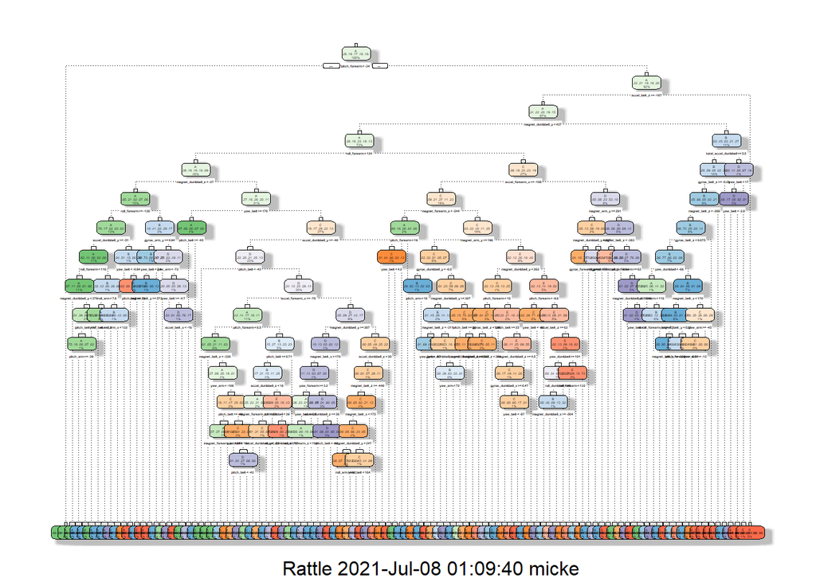

fig. 1: the tree of possible results of dumbbell lifting

```r
# Check the conditions
fancyRpartPlot(modFit$finalModel)
```

### Checking accuracy

For checking the accuracy of the model, I used the test set, split by me earlier:

```r
# Predict on the test case of the train
testing$predict <- predict(modFit,newdata=testing)
testing$classe <- factor(testing$classe)

# compare results with the test of the trail
confusionMatrix(testing$classe,testing$predict)
```

```
## Confusion Matrix and Statistics
##
##           Reference
## Prediction    A    B    C    D    E
##          A 1073   26    4    9    4
##          B   54  625   43   13   24
##          C    2   39  589   28   26
##          D   16   30   34  533   30
##          E   13   27   47   37  597
##
## Overall Statistics
##
##                Accuracy : 0.871
##                  95% CI : (0.8601, 0.8814)
##     No Information Rate : 0.2952
##     P-Value [Acc > NIR] : < 0.00000000000000022
##
##                   Kappa : 0.8366
##
##  Mcnemar's Test P-Value : 0.0004602
##
## Statistics by Class:
##
##                      Class: A Class: B Class: C Class: D Class: E
## Sensitivity            0.9266   0.8367   0.8215   0.8597   0.8767
## Specificity            0.9844   0.9578   0.9704   0.9667   0.9618
## Pos Pred Value         0.9615   0.8235   0.8611   0.8289   0.8280
## Neg Pred Value         0.9697   0.9614   0.9605   0.9735   0.9738
## Prevalence             0.2952   0.1904   0.1828   0.1580   0.1736
## Detection Rate         0.2735   0.1593   0.1501   0.1359   0.1522
## Detection Prevalence   0.2845   0.1935   0.1744   0.1639   0.1838
## Balanced Accuracy      0.9555   0.8972   0.8959   0.9132   0.9192
```

The check showed 87% accuracy. I, than used the validation set, as a duble check

```r
# Predict on the validation case of the train
validation$predict <- predict(modFit,newdata=validation)
validation$classe <- factor(validation$classe)

# compare results with the test of the train
confusionMatrix(validation$classe,validation$predict)
```

```
## Confusion Matrix and Statistics
##
##           Reference
## Prediction    A    B    C    D    E
##          A 1059   24   11   12   10
##          B   45  626   48   22   18
##          C    7   32  597   23   25
##          D   28   26   54  508   27
##          E   13   27   40   35  606
##
## Overall Statistics
##
##                Accuracy : 0.8657
##                  95% CI : (0.8546, 0.8762)
##     No Information Rate : 0.2937
##     P-Value [Acc > NIR] : < 0.00000000000000022
##
##                   Kappa : 0.8299
##
##  Mcnemar's Test P-Value : 0.00007244
##
## Statistics by Class:
##
##                      Class: A Class: B Class: C Class: D Class: E
## Sensitivity            0.9193   0.8517   0.7960   0.8467   0.8834
## Specificity            0.9794   0.9583   0.9726   0.9594   0.9645
## Pos Pred Value         0.9489   0.8248   0.8728   0.7900   0.8405
## Neg Pred Value         0.9669   0.9655   0.9528   0.9720   0.9750
## Prevalence             0.2937   0.1874   0.1912   0.1529   0.1749
## Detection Rate         0.2699   0.1596   0.1522   0.1295   0.1545
## Detection Prevalence   0.2845   0.1935   0.1744   0.1639   0.1838
## Balanced Accuracy      0.9494   0.9050   0.8843   0.9030   0.9239
```

This set showed a resembling accuracy of 86.5%, which means that the accuracy of the model is about ~86% and above to predict the performance of a subject, lifting dumbbell.

### Forecast: performing a prediction

As we now have the model to predict, I used this model to predict the outcome of 20 attempts to lift dumbbell, using a special dataset, which was not part of the train set, and provided separately:

```r
# predict on test values
predict(modFit,newdata=Source_prediction)
```

```
##  [1] B A B C A E D D A A C C B A E E A B B B
## Levels: A B C D E
```

These outcomes are the prediction of the system for 20 observation of test dataset, provided separately.

### Reference:

Velloso, E.; Bulling, A.; Gellersen, H.; Ugulino, W.; Fuks, H. Qualitative Activity Recognition of Weight Lifting Exercises. Proceedings of 4th International Conference in Cooperation with SIGCHI (Augmented Human ’13) . Stuttgart, Germany: ACM SIGCHI, 2013.